# Final Project: Impact of Public Policy on Covid Cases

## Introduction

Since emerging in late 2019, COVID-19 has swept across the world, leaving many to wonder how countries' governments should best respond to the crisis. Different countries had different responses. While many countries restricted traveling, closed schools, and instated mandatory working from home, Sweden was notable in its lack of nationwide lockdown and school closings. Citizens were encouraged to stay home when sick, but such recommendations were not enforced and relied soley on voluntary action. A more in-depth description of Sweden's preventative measures can be found here: https://www.nature.com/articles/s41599-022-01097-5.

This project seeks to examine how Sweden's public policy decisions impacted its COVID cases compared to those of other countries who had more restrictive public policies. These countries to compare against must be similar geographically and hava similar GDP per capita if order for this comparison to be meaningful. I decided on comparing Sweden to fellow Nordic countries Finland and Norway, both of whom have more restrictive COVID policies (Finland: https://yle.fi/news/3-11260062, Norway: https://www.nrk.no/norge/alle-utdanningsinstitusjoner-stenges-_-flere-arrangementer-og-virksomheter-far-forbud-1.14940952) and a relatively similar GDP per capita (https://data.worldbank.org/indicator/NY.GDP.PCAP.CD).

## Data Collection

When looking for a dataset on the COVID stats for countries, I used the class provided site that lists many different public datasets called https://github.com/awesomedata/awesome-public-datasets. The site is a great resource for any research project, hosting datasets for a variety of topics. On it, I found a dataset on COVID-19 cases in many different countries, which can be reached by going through https://dj2taa9i652rf.cloudfront.net/ > rearc-covid-19-world-cases-deaths-testing/ > json/. The dataset was contained as a json file, which I downloaded as "part-00000-8df47197-4c9a-4f0d-bf4a-d6d43ea1a317-c000.json". The file name changes whenever there's an update to the json dataset, so it no longer has the name I am using here, but the current file should have the same formatting as the one I use in this project. It contains columns describing the country, the country code, the date for a particular entry, the total cases in the country at that date, the number of new cases on that date, the total deaths in the country at that date, the number of new deaths that occurred on that date, the total number of cases per million of that country's population, the number of new cases per million of that country's population, the number of total deaths per million population, the number of new deaths per million of population, and testing data.

One of the best ways of storing tabular information like this is in Python DataFrames. DataFrames allow you to easily store, retrieve, and apply transformations on tabular data. For documentation on DataFrames, see https://pandas.pydata.org/docs/reference/api/pandas.DataFrame.html.

Since the original dataset was incredibly large and I only wanted to examine certain countries, I decided against having one DataFrame to contain all rows in the dataset. I'd have to continuously query the entire huge DataFrame for the information on a specific country, which is very inefficient. I instead decided to put the dataset information into a dictionary of DataFrames. The dictionary would have a specific country as the key, and the key's value would be all the rows in the original dataset belonging to that country (minus the columns indicating the country because that is redundant information). To do this, I imported Python's json and pandas packages, the former to read in the json file as a json object and the latter so I can use DataFrames. A more in depth webpage on json and reading in json files is https://docs.python.org/3/library/json.html.

```python
import json
import pandas as pd
```

I first wanted to read in the json file using the json.load() method. However, there turned out to be a problem in the downloaded json file. While each individual line is in the json format, the file itself was formatted incorrectly. Jupyter notebook (the computing platform I was doing this project on) wouldn't load an incorrectly-formatted json file, so I converted the json file to a text file (now called "part-00000-8df47197-4c9a-4f0d-bf4a-d6d43ea1a317-c000.txt") and read it line by line using Python's readlines method.

```python
with open('part-00000-8df47197-4c9a-4f0d-bf4a-d6d43ea1a317-c000.txt') as file:
    lines = file.readlines()
```

For each line the file, I then read in the row using the json.loads method, converting the row into a json object which can be parsed for column values. I then find the row's location value to figure out which key in the dictionary should have the row information be added to. To save time, since reading in the large file takes a considerable amount of time, I only read the rows into the dictionary if it is one of the countries I will eventually looking at: Sweden, Finland, or Norway. I do this by using an array with those countries names and skipping the processing if the row's location is not one of those 3 countries. If there doesn't already exist a DataFrame in the dictionary for that specific country, I created a new dataframe out of the column values to save as the location's value. Else, I created a list of the data values that will represent the new row to add to the existing DataFrame for that location.

However, in the dataset, there are json lines that use an entirely different format then the one I assumed when extracting the information about total cases and new cases. These are the rows about the aforementioned testing data in the dataset, and when I encountered these lines in the file and tried to parse out columns that didn't exist in those roles, I raised an error. Since I didn't want to include those rows as information in the dictionary anyway, I created a try-except block to catch these errors and just ignore those rows, i.e. rows that didn't match expected formatting weren't added into the dictionary of DataFrames.

The last formatting error that could occur is for rows of countries that are yet to have any deaths (but still have cases). Those lines do not have values for the columns of total deaths, new deaths, total deaths per million, new deaths per million, and thus when my code attempts to parse for those columns it throws an error because they don't exist. To account for this error, I use the DataFrame method "get" to retrieve the value of the column if it is provided and return the default value of 0 deaths if it is not.

This next section of code creates the dictionary of DataFrames as described above.

```python
total_dict = {}
loc_need = ['Sweden', 'Finland', 'Norway']

for line in lines:
    data = json.loads(line)
    loc = data["location"]

    # Only process data for needed countries.
    if loc not in loc_need:
        continue
    # If location is not in the dictionary yet, first create a DataFrame with the proper columns and without entries
    if total_dict.get(loc) is None:
        total_dict[loc] = pd.DataFrame(columns = ['date', 'total_cases', 'new_cases', 'total_deaths', 'new_deaths', 'total_cases_per_million', 'new_cases_per_million', \
                                                  'total_deaths_per_million', 'new_deaths_per_million'])

    # If the row doesn't have 'total_cases' columns, then the documentation is about test data, which we don't care about for the purpose of this project
    try:
        # The specific .get(parameter, 0) calls are for the 'death' columns.  In the original dataset, 0 values weren't included as columns at all, so we must include a default value manually
        values = [data['date'], data['total_cases'], data['new_cases'], data.get('total_deaths', 0), data.get('new_deaths', 0), data['total_cases_per_million'], \
                  data['new_cases_per_million'], data.get('total_deaths_per_million', 0), data.get('new_deaths_per_million', 0)]
        total_dict[loc].loc[len(total_dict[loc].index)] = values
    except:
        pass

# This print statement helps me tell when this incredibly time-consuming operation has finished.
print("Finished operation")
```

```
Finished operation
```

```python
data_copy = total_dict
```

## Data Representation

I want to display multiple graphs of different countries' covid statistics as they change over time, so to do that I imported the Pyplot MatPlotLib packages. The Pyplot package allows us to plot multiple graphs with the same axes for easier comparison with each other. More information on Pyplot and its applications can be found at https://matplotlib.org/3.5.0/api/_as_gen/matplotlib.pyplot.html.

```python
import matplotlib.pyplot as plt
```

### Sweden

First, I converted the date column from a string to a datetime using pandas' to_datetime method. This allows us to plot COVID statistics as a function of dates.

```python
data_copy['Sweden']['date'] = pd.to_datetime(total_dict['Sweden']['date'])
```

I then displayed a plot of Sweden's total number of COVID cases over time as a line graph using Pyplot's plot function. This step is in a separate code block from the earlier column creation code because, if we wanted to re-run the code that creates our first graph, we don't have to go through the process of converting the date column to a datetime, since it is already that type.

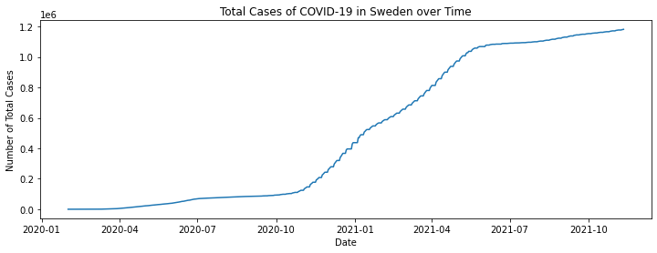

```python
fig = plt.figure()
fig.set_figwidth(12)
plt.title("Total Cases of COVID-19 in Sweden over Time")
plt.xlabel("Date")
plt.ylabel("Number of Total Cases")
plt.plot(data_copy['Sweden']['date'], data_copy['Sweden']['total_cases'])
plt.show()
```

You can see how the total cases in Sweden increases at a slow rate at first, before increasing considerably more steeply towards the end of 2020 and then leveling off again around May-June 2021.

Comparing countries' total cases isn't very meaningful considering how Sweden, Finland, and Norway all have different population sizes. It would be better to view Sweden's total cases per million of its population over time, which is the next graph being displayed.

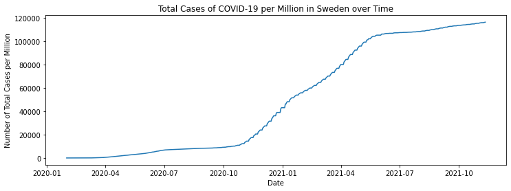

```python
fig = plt.figure()
fig.set_figwidth(12)
plt.title("Total Cases of COVID-19 per Million in Sweden over Time")
plt.xlabel("Date")
plt.ylabel("Number of Total Cases per Million")
plt.plot(data_copy['Sweden']['date'], data_copy['Sweden']['total_cases_per_million'])
plt.show()
```

You can see that the only thing that changes between the two graphs is the Y-axis, which is scaled to be the proportion of cases in relation to one million of Sweden's population - the shape of the graph remains the same since we're still measuring the same statistic.

Another statistic I want to display is the number of new cases of COVID in Sweden over time. Since total cases is cumulative, I wanted to see the number of cases for a specific day. Perhaps that could give some insight into how a country's protocols helped or hurt its COVID-19 situation over time.

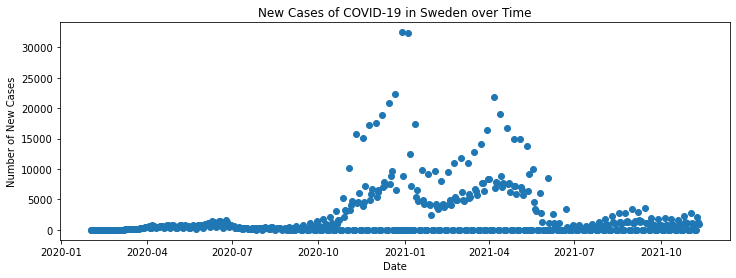

```python
fig = plt.figure()
fig.set_figwidth(12)
plt.title("New Cases of COVID-19 in Sweden over Time")
plt.xlabel("Date")
plt.ylabel("Number of New Cases")
plt.scatter(data_copy['Sweden']['date'], data_copy['Sweden']['new_cases'], linewidths=1)
plt.show()
```

It seems that the number of new cases in Sweden were very low for most of the timeframe, but from late 2020 to the first half of 2021 there were huge peaks of new cases, matching up to the sharp increase in total cases in the previous graphs.

Like with the total cases of Sweden earlier, I also displayed the new cases of COVID in proportion to population size as well.

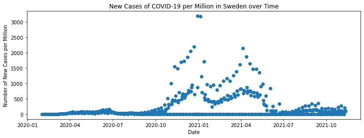

```python
fig = plt.figure()
fig.set_figwidth(12)
plt.title("New Cases of COVID-19 per Million in Sweden over Time")
plt.xlabel("Date")
plt.ylabel("Number of New Cases per Million")
plt.scatter(data_copy['Sweden']['date'], data_copy['Sweden']['new_cases_per_million'], linewidths=1)
plt.show()
```

Again, the only change is the Y-axis, which is scaled to be the proportion of cases in relation to one million of Sweden's population.

Now that we have an idea of what Sweden's COVID-19 cases looked like over time, let's compare Sweden to other Nordic countries.

### Finland

First, we convert Finland's date column to a datetime format as we did with Sweden so that it can be used to plot Finland's COVID-19 cases.

```python
data_copy['Finland']['date'] = pd.to_datetime(total_dict['Finland']['date'])
```

Since we're mostly interested in Finland in terms of how it compares versus Sweden, we'll only be looking at the "per million" case statistics. Thus, the first graph we will be displaying is Finland's total cases of COVID per million of its population over time.

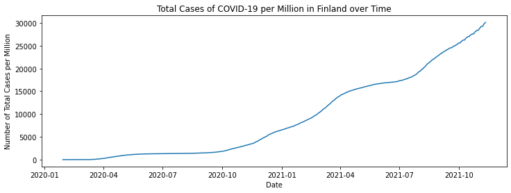

```python
fig = plt.figure()
fig.set_figwidth(12)
plt.title("Total Cases of COVID-19 per Million in Finland over Time")
plt.ylabel("Number of Total Cases per Million")
plt.xlabel("Date")
plt.plot(data_copy['Finland']['date'], data_copy['Finland']['total_cases_per_million'])
plt.show()
```

Immediately we can see that the shape of the graph is siginificaly different from Sweden's. This graph is more of a gentle but continuous parabolic increase, with only a few instances of steeper growths in total cases. However, it is hard to truly compare it against Sweden's graph since they have different Y-axis. This will be revisited in a later section.

The next graph to create is Finland's new cases of COVID per million of its population over time.

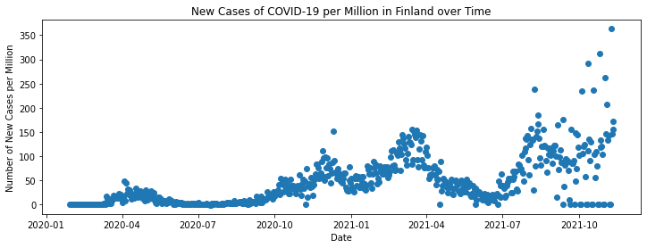

```python
fig = plt.figure()
fig.set_figwidth(12)
plt.title("New Cases of COVID-19 per Million in Finland over Time")
plt.ylabel("Number of New Cases per Million")
plt.xlabel("Date")
plt.scatter(data_copy['Finland']['date'], data_copy['Finland']['new_cases_per_million'], linewidths=1)
plt.show()
```

This graph is also different from Sweden's. Sweden's graph had peaks in the middle of the time period, while Finland has fairly continuous peaks that seem to increase the later the date is. The increase in new cases towards the latter part the time frame could be explained by Finland relaxing its COVID-19 restrictions during the second half of 2021 to be something more similar to Sweden's policies. The effect of this policy change, in terms of number of covid-19 cases in Finland as a result of its relaxed restrictions, can be observed in the resemblance of the shape of the last peak between July 2021 and November 2021 to the shape of Sweden's middle peak between October 2020 and June 2021. The peaks in Finland's graph also roughly match up date-wise with the steeper increases in its "total cases per million" graph.

### Norway

As with Sweden and Finland, we convert Norway's date column to a datetime format so that it can be used to plot Finland's COVID-19 cases.

```python
data_copy['Norway']['date'] = pd.to_datetime(total_dict['Norway']['date'])
```

Like before, we're mostly interested in how Norway compares to Sweden, so we'll only be looking at the "per million" case statistics. The next graph we will be displaying is Norway's total cases of COVID per million of its population over time.

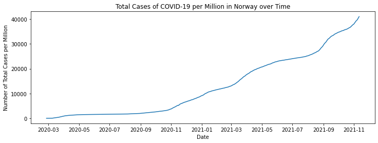

```python
fig = plt.figure()
fig.set_figwidth(12)
plt.title("Total Cases of COVID-19 per Million in Norway over Time")
plt.ylabel("Number of Total Cases per Million")
plt.xlabel("Date")
plt.plot(data_copy['Norway']['date'], data_copy['Norway']['total_cases_per_million'])
plt.show()
```

This graph looks very similar to the shape of Finland's total cases of COVID-19 over time - a gentle polynomial increase over time with some instances of steeper increases of total cases.

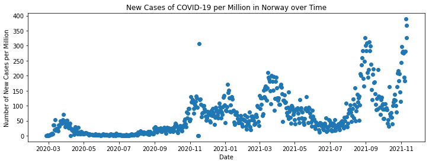

```python
fig = plt.figure()
fig.set_figwidth(12)
plt.title("New Cases of COVID-19 per Million in Norway over Time")
plt.ylabel("Number of New Cases per Million")
plt.xlabel("Date")
plt.scatter(data_copy['Norway']['date'], data_copy['Norway']['new_cases_per_million'], linewidths=1)
plt.show()
```

The peaks in Norway's "new cases per million" graph also roughly match up date-wise with the steeper increases in its "total cases per million" graph. These peaks seem more "solid" than Sweden's peaks in that dates' new case numbers tend to be very close together to form "thicker" lines.

### Grouped Displays

As mentioned before, it is hard to compare the graphs between the various countries with their different y-axes. So, I used MatPlotLib's subplots function to put them together on the same axes (documentation found here: https://matplotlib.org/3.5.0/api/_as_gen/matplotlib.pyplot.subplots.html).

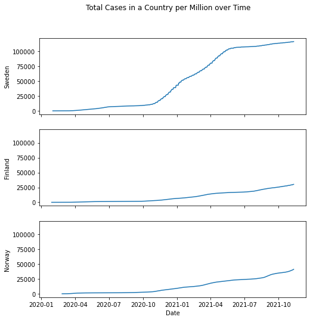

```python
fig, (ax1, ax2, ax3) = plt.subplots(3, sharex=True, sharey=True)
fig.set_figwidth(8)
fig.set_figheight(8)
fig.suptitle('Total Cases in a Country per Million over Time')

# Sweden
ax1.plot(data_copy['Sweden']['date'], data_copy['Sweden']['total_cases_per_million'])
ax1.set_ylabel("Sweden")

# Finland
ax2.plot(data_copy['Finland']['date'], data_copy['Finland']['total_cases_per_million'])
ax2.set_ylabel("Finland")

# Norway
ax3.plot(data_copy['Norway']['date'], data_copy['Norway']['total_cases_per_million'])
ax3.set_ylabel("Norway")

ax3.set_xlabel("Date")
plt.show()
```

It is suddenly very clear that the "steep" increases found in Finland's and Norway's total cases graphs are very inconsequential when compared to the steep increase in total cases that Sweden went through. Sweden ends with the highest total cases per million by far, which could be a result of its lax COVID protocols.

We then compare the "new cases per million" graphs for the 3 countries.

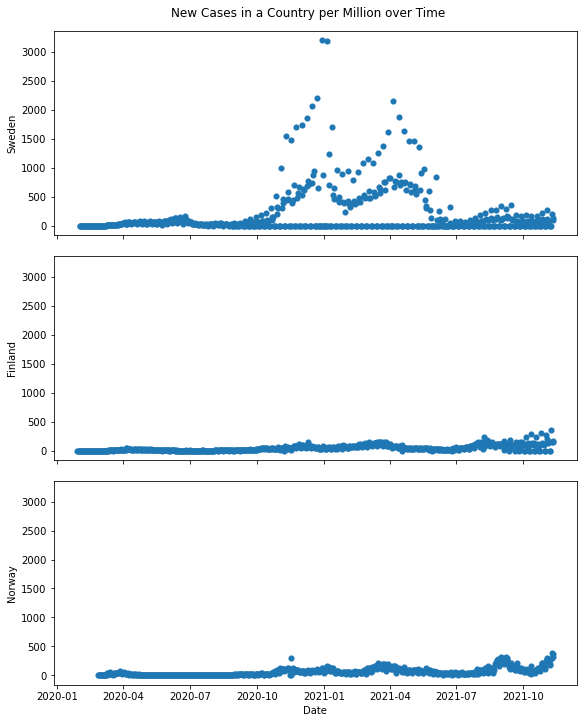

```python
fig, (ax1, ax2, ax3) = plt.subplots(3, sharex=True, sharey=True)
fig.set_figwidth(8)
fig.set_figheight(10)
fig.suptitle('New Cases in a Country per Million over Time')
fig.tight_layout()

# Sweden
ax1.scatter(data_copy['Sweden']['date'], data_copy['Sweden']['new_cases_per_million'], linewidth=0.1)
ax1.set_ylabel("Sweden")

# Finland
ax2.scatter(data_copy['Finland']['date'], data_copy['Finland']['new_cases_per_million'], linewidth=0.1)
ax2.set_ylabel("Finland")

# Norway
ax3.scatter(data_copy['Norway']['date'], data_copy['Norway']['new_cases_per_million'], linewidth=0.1)
ax3.set_ylabel("Norway")

ax3.set_xlabel("Date")
plt.show()
```

Again, Sweden appears to be the outlier between the 3 countries - Finland and Norway's new cases numbers stay relatively consistently low except for a slight increase towards the end. Sweden has huge peaks in outbreaks and new case numbers, far beyond the scope achieved by the other 2 countries. While Norway and Finland never have more than 500 new cases per 1 million of population a day, Sweden has had days where it had more than 3000 new cases per million of population. It appears that Sweden's loose protocols leads to the possibility of greater outbreaks of cases a day, but more analysis is necessary to reach a full conclusion.

## Exploratory Data Analysis

### Total Cases per Million

For the first part of my exploratory data analysis, I want to create a linear regression line for the "total cases per million" graphs. In order to put the dates into a linear regression fit as an independent variable, I had to convert them into a number representation. To do so, I decided to import MatPlotLib's dates package for its date2num method that converts datetime objects into Matplotlib dates. Using that method, I created a new column in each of the country's DataFrames to hold that a row's date's numerical representation.

```python
import matplotlib.dates
data_copy['Sweden']['date_num'] = matplotlib.dates.date2num(data_copy['Sweden']['date'])
data_copy['Finland']['date_num'] = matplotlib.dates.date2num(data_copy['Finland']['date'])
data_copy['Norway']['date_num'] = matplotlib.dates.date2num(data_copy['Norway']['date'])
```

To create a linear regression line, I used Sklearn's linear model's LinearRegression function that takes in a set of independent and dependent variables and creates a line of best fit that minimizes the residual sum of squares between the provided data and the predicted line. More information on this function can be found here: https://scikit-learn.org/stable/modules/generated/sklearn.linear_model.LinearRegression.html

```python
import numpy as np
from sklearn.linear_model import LinearRegression
```

For each country, we create a Numpy array of x values (the numerical date representation) and another for y values (the total cases per million for that day). The x array must be reshaped before both are put into the Linear Regression's fit function, which will create a Linear Regression object that can predict total cases per million given a date (in numerical representation). We then create a column in each country's DataFrame that holds the expected total cases per million for each date so we can plot the linear regression later.

```python
# Create linear regression for Sweden
sweden_x = np.array(data_copy['Sweden']['date_num'].tolist())
sweden_y = np.array(data_copy['Sweden']['total_cases_per_million'].tolist())
sweden_x = sweden_x.reshape((-1,1))
reg_sweden = LinearRegression().fit(sweden_x, sweden_y)
data_copy['Sweden']['reg_line'] = data_copy['Sweden'].apply (lambda row: reg_sweden.predict(np.array([row.date_num]).reshape((-1,1)))[0], axis=1)

# Create linear regression for Finland
finland_x = np.array(data_copy['Finland']['date_num'].tolist())
finland_y = np.array(data_copy['Finland']['total_cases_per_million'].tolist())
finland_x = finland_x.reshape((-1,1))
reg_finland = LinearRegression().fit(finland_x, finland_y)
data_copy['Finland']['reg_line'] = data_copy['Finland'].apply (lambda row: reg_finland.predict(np.array([row.date_num]).reshape((-1,1)))[0], axis=1)

# Create linear regression for Norway
norway_x = np.array(data_copy['Norway']['date_num'].tolist())
norway_y = np.array(data_copy['Norway']['total_cases_per_million'].tolist())
norway_x = norway_x.reshape((-1,1))
reg_norway = LinearRegression().fit(norway_x, norway_y)
data_copy['Norway']['reg_line'] = data_copy['Norway'].apply (lambda row: reg_norway.predict(np.array([row.date_num]).reshape((-1,1)))[0], axis=1)
```

This next code block is for displaying the linear regressions within graphs containing the original data they were created from. For each of the countries, we also take the slope of its corresponding linear regression line using .coef_[0] and print it out next to its graph.

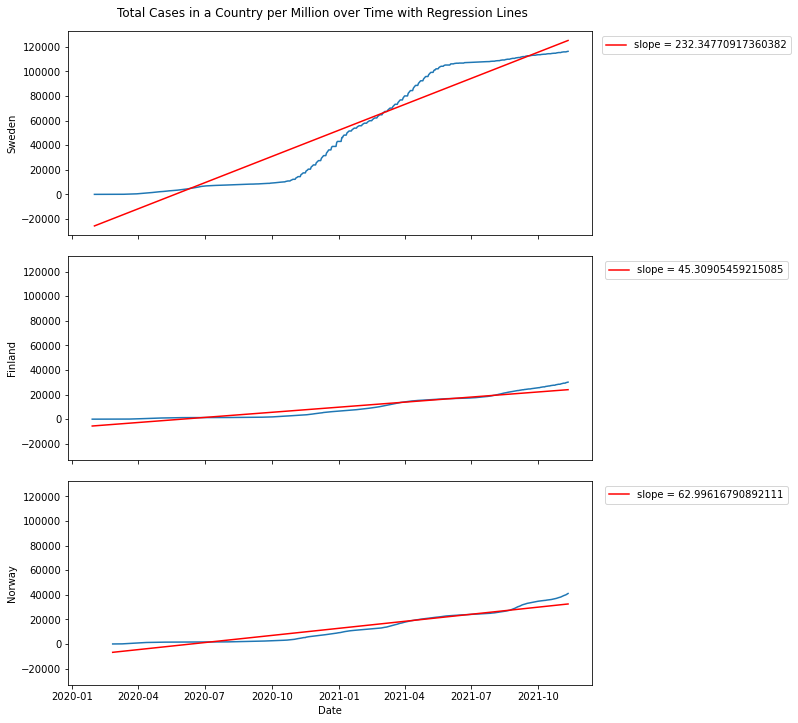

```python
fig, (ax1, ax2, ax3) = plt.subplots(3, sharex=True, sharey=True)
fig.set_figwidth(8)
fig.set_figheight(10)
fig.suptitle('Total Cases in a Country per Million over Time with Regression Lines')
fig.tight_layout()

# Sweden
ax1.plot(data_copy['Sweden']['date'], data_copy['Sweden']['total_cases_per_million'])
ax1.set_ylabel("Sweden")
slope_sweden = "slope = " + str(reg_sweden.coef_[0])
ax1.plot(data_copy['Sweden']['date'], data_copy['Sweden']['reg_line'], color="red", label=slope_sweden)
ax1.legend(bbox_to_anchor = (1.2, 1), loc = 'upper center')

# Finland
ax2.plot(data_copy['Finland']['date'], data_copy['Finland']['total_cases_per_million'])
ax2.set_ylabel("Finland")
slope_finland = "slope = " + str(reg_finland.coef_[0])
ax2.plot(data_copy['Finland']['date'], data_copy['Finland']['reg_line'], color="red", label=slope_finland)
ax2.legend(bbox_to_anchor = (1.2, 1), loc = 'upper center')

# Norway
ax3.plot(data_copy['Norway']['date'], data_copy['Norway']['total_cases_per_million'])
ax3.set_ylabel("Norway")
slope_norway = "slope = " + str(reg_norway.coef_[0])
ax3.plot(data_copy['Norway']['date'], data_copy['Norway']['reg_line'], color="red", label=slope_norway)
ax3.legend(bbox_to_anchor = (1.2, 1), loc = 'upper center')

ax3.set_xlabel("Date")
plt.show()
```

Since the original values can obfuscate the linear regression line, I also printed out the graphs only displaying the regression line.

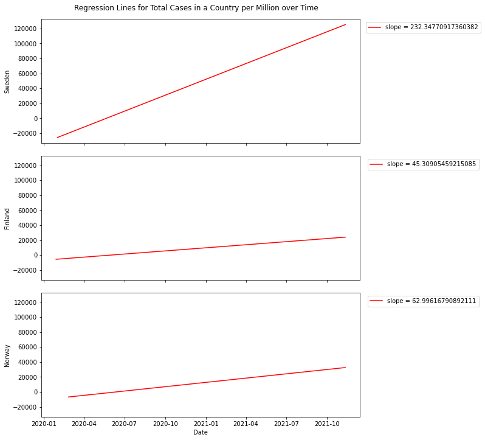

```python
fig, (ax1, ax2, ax3) = plt.subplots(3, sharex=True, sharey=True)
fig.set_figwidth(8)
fig.set_figheight(10)
fig.suptitle('Regression Lines for Total Cases in a Country per Million over Time')
fig.tight_layout()

# Sweden
ax1.set_ylabel("Sweden")
slope_sweden = "slope = " + str(reg_sweden.coef_[0])
ax1.plot(data_copy['Sweden']['date'], data_copy['Sweden']['reg_line'], color="red", label=slope_sweden)
ax1.legend(bbox_to_anchor = (1.2, 1), loc = 'upper center')


# Finland
ax2.set_ylabel("Finland")
slope_finland = "slope = " + str(reg_finland.coef_[0])
ax2.plot(data_copy['Finland']['date'], data_copy['Finland']['reg_line'], color="red", label=slope_finland)
ax2.legend(bbox_to_anchor = (1.2, 1), loc = 'upper center')


# Norway
ax3.set_ylabel("Norway")
slope_norway = "slope = " + str(reg_norway.coef_[0])
ax3.plot(data_copy['Norway']['date'], data_copy['Norway']['reg_line'], color="red", label=slope_norway)
ax3.legend(bbox_to_anchor = (1.2, 1), loc = 'upper center')

ax3.set_xlabel("Date")
plt.show()
```

Without the original data, it is even more clear the differences in the slopes of Sweden versus that of Finland and Norway. Again, this suggests that Sweden's lax public policy, a main differentiator between it and its fellow Nordic countries, causes a significant increase in the number of total cases per million of a country's population.

### New Cases per Million

I would next like to compare the average number of new cases per million between the various countries. So, I create the plots as I've done before, but this time I also calculate the mean value for a country's "new cases per million" column, which I will plot as a horizontal line in the graph using MatPlotLib's axhline function. We can then compare the heights of these horizontal lines between the various countries.

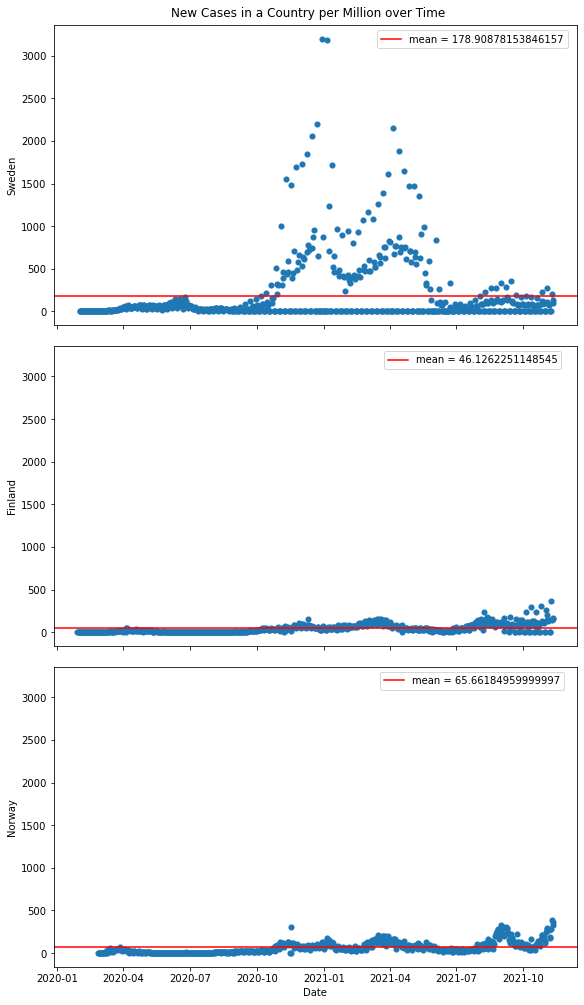

```python
fig, (ax1, ax2, ax3) = plt.subplots(3, sharex=True, sharey=True)
fig.set_figwidth(8)
fig.set_figheight(14)
fig.suptitle('New Cases in a Country per Million over Time')
fig.tight_layout()

# Sweden
ax1.scatter(data_copy['Sweden']['date'], data_copy['Sweden']['new_cases_per_million'], linewidth=0.1)
ax1.set_ylabel("Sweden")
sweden_mean = data_copy['Sweden']['new_cases_per_million'].mean()
sweden_label = "mean = " + str(sweden_mean)
ax1.axhline(sweden_mean, color="red", label=sweden_label)
ax1.legend(bbox_to_anchor = (0.8, 1), loc = 'upper center')
#ax1.text(1,1.51,("y = ", sweden_mean),rotation=360)

# Finland
ax2.scatter(data_copy['Finland']['date'], data_copy['Finland']['new_cases_per_million'], linewidth=0.1)
ax2.set_ylabel("Finland")
finland_mean = data_copy['Finland']['new_cases_per_million'].mean()
finland_label = "mean = " + str(finland_mean)
ax2.axhline(finland_mean, color="red", label=finland_label)
ax2.legend(bbox_to_anchor = (0.8, 1), loc = 'upper center')

# Norway
ax3.scatter(data_copy['Norway']['date'], data_copy['Norway']['new_cases_per_million'], linewidth=0.1)
ax3.set_ylabel("Norway")
norway_mean = data_copy['Norway']['new_cases_per_million'].mean()
norway_label = "mean = " + str(norway_mean)
ax3.axhline(norway_mean, color="red", label=norway_label)
ax3.legend(bbox_to_anchor = (0.8, 1), loc = 'upper center')

ax3.set_xlabel("Date")
plt.show()
```

Looking at these graphs, Sweden's mean of 178.9 appears to be surprisingly low due to its upper outliers, but it is still considerably higher than Finland's mean of 46.1 and Norway's mean of 65.7. This again suggests that Sweden's public policy leads to a greater average of new cases per million of a country's population a day. However, mean is a statistic easily swayed by outliers, of which Sweden's distribution has in abundance. We will do the above plot again, but with the central tendency median instead.

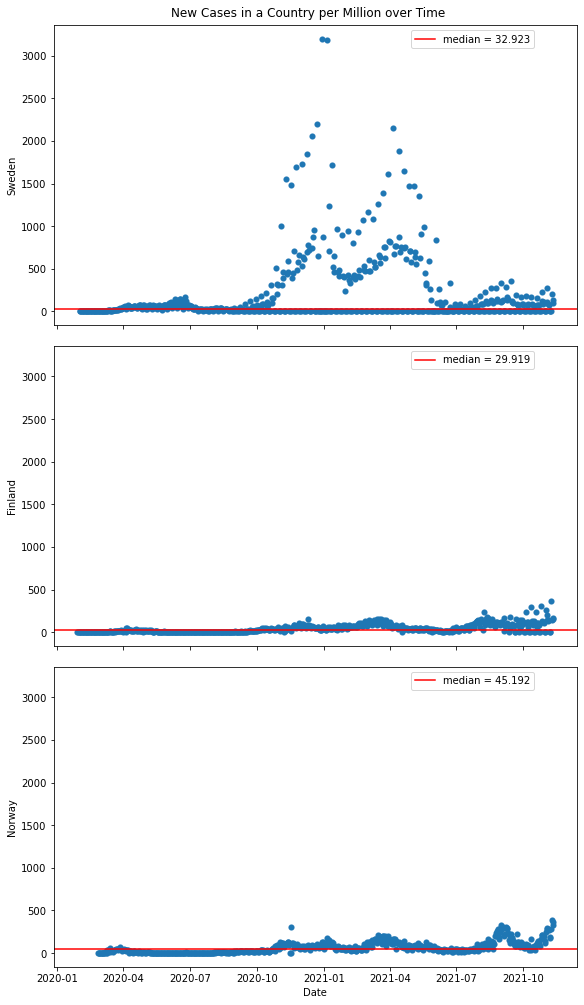

```python
fig, (ax1, ax2, ax3) = plt.subplots(3, sharex=True, sharey=True)
fig.set_figwidth(8)
fig.set_figheight(14)
fig.suptitle('New Cases in a Country per Million over Time')
fig.tight_layout()

# Sweden
ax1.scatter(data_copy['Sweden']['date'], data_copy['Sweden']['new_cases_per_million'], linewidth=0.1)
ax1.set_ylabel("Sweden")
sweden_median = data_copy['Sweden']['new_cases_per_million'].median()
sweden_label = "median = " + str(sweden_median)
ax1.axhline(sweden_median, color="red", label=sweden_label)
ax1.legend(bbox_to_anchor = (0.8, 1), loc = 'upper center')
#ax1.text(1,1.51,("y = ", sweden_mean),rotation=360)

# Finland
ax2.scatter(data_copy['Finland']['date'], data_copy['Finland']['new_cases_per_million'], linewidth=0.1)
ax2.set_ylabel("Finland")
finland_median = data_copy['Finland']['new_cases_per_million'].median()
finland_label = "median = " + str(finland_median)
ax2.axhline(finland_median, color="red", label=finland_label)
ax2.legend(bbox_to_anchor = (0.8, 1), loc = 'upper center')

# Norway
ax3.scatter(data_copy['Norway']['date'], data_copy['Norway']['new_cases_per_million'], linewidth=0.1)
ax3.set_ylabel("Norway")
norway_median = data_copy['Norway']['new_cases_per_million'].median()
norway_label = "median = " + str(norway_median)
ax3.axhline(norway_median, color="red", label=norway_label)
ax3.legend(bbox_to_anchor = (0.8, 1), loc = 'upper center')

ax3.set_xlabel("Date")
plt.show()
```

The results of the median operation have different rankings than that of the mean. Notably, Norway's distribution is the country with the highest median at 45.192, while Sweden has a smaller median at 32.923, indicating that Sweden's number of new cases per million distribution isn't all that different than that of the other Nordic countries. The conflicting conclusions drawn from looking at the median versus the mean suggests that basing the differences between country's new cases per million statistic using central tendency measurements alone yields inconclusive results. So, in order to come to a more conclusive conclusion, we will move onto doing hypothesis testing.

## Hypothesis Testing

### Kolmogorov-Smirnov Test

```python
from scipy.stats import ks_2samp

# alternate = "less" means that we're testing for Finland or Norway to have a smaller distribution than Sweden
print("Sweden vs Finland:", ks_2samp(data_copy['Sweden']['total_cases_per_million'], data_copy['Finland']['total_cases_per_million'], alternative='less', mode='asymp'))
print("Sweden vs Norway:", ks_2samp(data_copy['Sweden']['total_cases_per_million'], data_copy['Norway']['total_cases_per_million'], alternative='less', mode='asymp'))
```

```
Sweden vs Finland: KstestResult(statistic=0.518468606431853, pvalue=5.2194548461567866e-77)
Sweden vs Norway: KstestResult(statistic=0.48923076923076925, pvalue=3.533472753712048e-67)
```

All of the p values were smaller than the alpha of a = 0.05, indicating that we can reject the null hypothesis of the distributions being from the same population and accept the alternative hypothesis that Sweden has a generally larger distribution of total cases per million than Finland or Norway.

### Polynomial Regression Fitting

In addition to the evidence from looking at the Kolmogorov-Smirnov Test, I will also be fitting the "total cases per million" distributions of the Nordic countries to 2nd degree polynomial regressions, since "total cases per million" distributions function as a continuous distribution. I believe that, with restrictive policies, Finland and Norway will have a slow, quadratic regression. However, Sweden with its more open policy will be more unpredictable, since one person with COVID could spread it to considerably more people since they aren't forced to quarantine, causing more dates of steep increases and thus causing the distribution to not match its polynomial regressions as well as Finland's and Norway's would. We can do a least square polynomial fit using NumPy's polyfit() method, which takes in the independent and dependent variables to fit on, as well as the number of dimensions we will be fitting on. The result returned is the coefficients of the model (more information on it can be found at https://numpy.org/doc/stable/reference/generated/numpy.polyfit.html).

#### Finland

First, to fit the 2-dimensional polynomial regression we take the values that will act as the dependent variable y (total cases per million) and x (the numerical representations of the date) and put it in the function. We can then put the resulting polynomial coefficients into NumPy's poly1d() function, which produces a polynomial class that can predict a country's total cases per million based on a provided date. (More information on poly1d can be found at https://numpy.org/doc/stable/reference/generated/numpy.poly1d.html).

However, the first thing we must do is split the x and y values into training and testing sets; we don't want to create the regression on all of our data in case we overfit and create a regression that does not accurately describe the phenomenon but just that particular data set. We will split our data values using Sklearn's model selection's train_test_split function, which splits arrays into random train and test subsets. We will use 80% of the data for training and 20% of the data for testing. We specify the "shuffle" argument as true since currently the data is sorted in order of date, and we want a sampling of random dates. You can find more information on the train_test_split at https://scikit-learn.org/stable/modules/generated/sklearn.model_selection.train_test_split.html.

```python
from sklearn.model_selection import train_test_split
```

We first create a polynomial regression for Finland using the process described above.

```python
finland_y = data_copy['Finland']['total_cases_per_million']
finland_x = data_copy['Finland']['date_num']

fin_x_train, fin_x_test, fin_y_train, fin_y_test = train_test_split(finland_x, finland_y, test_size = 0.2, random_state=0, shuffle=True)
finland_poly = np.polyfit(fin_x_train, fin_y_train, 2)
predict_finland = np.poly1d(finland_poly)
```

We then want to display the polynomial regression alongside the data used to create it using MatPlotLib as we've done for earlier graphs.

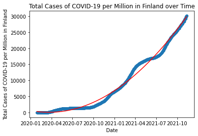

```python
plt.scatter(data_copy['Finland']['date'], data_copy['Finland']['total_cases_per_million'], linewidth=0.1)
plt.title("Total Cases of COVID-19 per Million in Finland over Time")
plt.ylabel("Total Cases of COVID-19 per Million in Finland")
plt.xlabel("Date")
plt.plot(data_copy['Finland']['date'], predict_finland(data_copy['Finland']['date_num']), color="red")
plt.show()
```

To analyze how well the polynomial regression matched the data, we run a R squared regression score test on how well the polynomial regression predicts the test data we've set aside for this purpose. The closer to 1, the more accurate.

```python
from sklearn.metrics import r2_score

print("R-squared score for Finland:", r2_score(fin_y_test, predict_finland(fin_x_test)))
```

```
R-squared score for Finland: 0.9894392484214222
```

The resulting R-sqared score is 0.99, which is incredibly close to 1. The high R square score indicates that Finland's 2nd order polynomial regression fit the test data curve, so Finland's total cases per million distribution can be represented by a quadratic regression.

#### Norway

For Norway, we follow a similar process to how we did Finland.

```python
norway_y = data_copy['Norway']['total_cases_per_million']
norway_x = data_copy['Norway']['date_num']

nor_x_train, nor_x_test, nor_y_train, nor_y_test = train_test_split(norway_x, norway_y, test_size = 0.2, random_state=0, shuffle=True)
norway_poly = np.polyfit(nor_x_train, nor_y_train, 2)
predict_norway = np.poly1d(norway_poly)
```

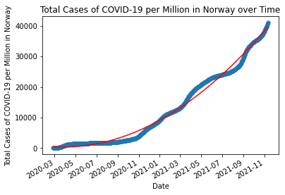

```python
plt.scatter(data_copy['Norway']['date'], data_copy['Norway']['total_cases_per_million'], linewidth=0.1)
plt.title("Total Cases of COVID-19 per Million in Norway over Time")
plt.ylabel("Total Cases of COVID-19 per Million in Norway")
plt.xlabel("Date")

# To prevent x-axis labels from overlapping
plt.gcf().autofmt_xdate()

plt.plot(data_copy['Norway']['date'], predict_norway(data_copy['Norway']['date_num']), color="red")
plt.show()
```

```python
print("R-squared score for Norway:", r2_score(nor_y_test, predict_norway(nor_x_test)))
```

```
R-squared score for Norway: 0.9894100754681175
```

This R-squared value is also incredibly high, with the same rounded value of 0.99, showing that Norway's 2nd order polynomial regression fits the test data curve and that Norway's total cases per million distribution can be represented by a quadratic regression well.

#### Sweden

Now we fit Sweden to a 2nd degree polynomial regression.

```python
sweden_y = data_copy['Sweden']['total_cases_per_million']
sweden_x = data_copy['Sweden']['date_num']

swe_x_train, swe_x_test, swe_y_train, swe_y_test = train_test_split(sweden_x, sweden_y, test_size = 0.2, random_state=0, shuffle=True)
sweden_poly = np.polyfit(swe_x_train, swe_y_train, 2)
predict_sweden = np.poly1d(sweden_poly)
```

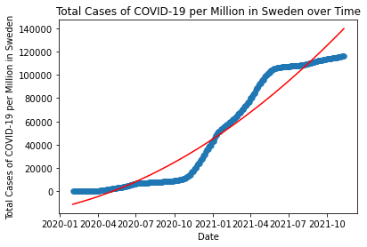

```python
plt.scatter(data_copy['Sweden']['date'], data_copy['Sweden']['total_cases_per_million'], linewidth=0.1)
plt.title("Total Cases of COVID-19 per Million in Sweden over Time")
plt.ylabel("Total Cases of COVID-19 per Million in Sweden")
plt.xlabel("Date")
plt.plot(data_copy['Sweden']['date'], predict_sweden(data_copy['Sweden']['date_num']), color="red")
plt.show()
```

Immediately one can see that Sweden's total cases per million graph doesn't like up with the predicted curve as well as Norway's and Finland's did. However, we need to do an R-squared score calculation to get more concrete evidence.

```python
print("R-squared score for Sweden:", r2_score(swe_y_test, predict_sweden(swe_x_test)))
```

```
R-squared score for Sweden: 0.9327127332321198
```

Compared to Finland's R-squared score of 0.99 and Norway's R-squared score of 0.99, Sweden's R-squared score of 0.93 is relatively low, and the plot also shows the eraticness of Sweden's distribution compared to the quadratic prediction line.

## Communication of Insights Attained

In this project, by using the Nordic countries as an example of countries in a relatively isolated region with similar high GDP per capita, we found that the country with more lax COVID protocols has a higher distribution of total cases of COVID per million population than countries with stricter COVID protocols. We also found that, for countries with more strict COVID protocols, the total number of cases per million population follows a more predictable behavior according to the progression line.

It is important to analyze the impacts of countries' public policies regarding COVID because the public policy that countries instate has direct impact on the number of cases that arise within their population, and in the worst case, can cause spikes that overwhelm the country's healthcare system. Increased covid cases means increased hospital occupacy and possible increased death rate. With these findings in mind, we can recommend stricter COVID-19 public policy to decrease the number of total cases in countries and to also allow the countries' health system to plan their resources to handle the cases in a more predictable manner.